```python
# Environment setup

!pip install scanpy anndata seaborn plotly scikit-misc
```

# 1 - Single-cell RNA-seq descriptive analysis

This part of the notebook walks through a structured descriptive analysis of a single-cell RNA-seq dataset stored in an `AnnData` object (`adata`). The main goals are:

- compute **per-cell** and **per-gene** QC metrics,
- derive **biological QC** per gene family (mt / ribo / hemo / Ig),
- explore **correlations** between QC metrics and gene-family percentages,
- identify **top genes** by mean expression, detection rate and CV²,
- inspect the **training label distribution**,
- obtain low-dimensional views of the data with **PCA** and **UMAP** (static + interactive).

Each numbered section below consists of a short markdown description and a corresponding code cell.

```python
# Setup: imports, paths, helper functions

from pathlib import Path
from contextlib import contextmanager

import numpy as np
import pandas as pd

from scipy import sparse

import matplotlib.pyplot as plt
from matplotlib.ticker import MaxNLocator
import seaborn as sns

import scanpy as sc
import plotly.graph_objects as go
from plotly.colors import qualitative

# Paths and directories
FIG_DIR = Path("figs_descriptive")
DESCR_DIR = Path("descriptive_outputs")
FIG_DIR.mkdir(parents=True, exist_ok=True)
DESCR_DIR.mkdir(parents=True, exist_ok=True)

TRAIN_CSV_PATH = Path("/content/singlecell_train.csv")
TRAIN_ID_COL = "ID"
TRAIN_LABEL_COL = "cell_type"

# Scanpy plotting defaults
sc.settings.set_figure_params(figsize=(6, 5), dpi=100)
sc.settings.figdir = str(FIG_DIR)

#  Simple logging and section utilities
def log(msg: str):
    print(msg)


@contextmanager
def section(title: str):
    print(f"\n=== {title} ===")
    try:
        yield
    finally:
        print(f"--- End of section: {title} ---")


#  Generic helpers
def to_dense(X):
    """Convert sparse matrix to a dense NumPy array, otherwise return X as a NumPy array."""
    if hasattr(X, "A"):      # scipy sparse
        return X.A
    if hasattr(X, "toarray"):
        return X.toarray()
    return np.asarray(X)


def safe_to_1d(arr):
    """Convert array-like to a flattened 1D NumPy array."""
    arr = np.asarray(arr)
    return arr.ravel()


def describe_vector(x, name: str):
    """Print a short numeric summary (min/quantiles/mean/max) of a numeric vector."""
    vals = np.asarray(x, dtype=float)
    qs = np.percentile(vals, [0, 5, 25, 50, 75, 95, 100])
    print(f"\n--- {name} ---")
    print(f"  min   = {qs[0]:.3f}")
    print(f"  p05   = {qs[1]:.3f}")
    print(f"  p25   = {qs[2]:.3f}")
    print(f"  median= {qs[3]:.3f}")
    print(f"  mean  = {vals.mean():.3f}")
    print(f"  p75   = {qs[4]:.3f}")
    print(f"  p95   = {qs[5]:.3f}")
    print(f"  max   = {qs[6]:.3f}")

# Plotting style
sns.set(style="whitegrid")
```

## Load data

Here we load the `AnnData` object from disk (e.g. a `.h5ad` file) into the variable `adata` using `scanpy.read_h5ad`.

The cell reports the number of cells (`n_obs`) and genes (`n_vars`) and sets the starting point for all subsequent analyses.

# Nuova sezione

```python
# 2. Load AnnData object

with section("Load AnnData object"):
    adata = sc.read_h5ad("/content/single_cell.h5ad")

    log(f"adata has shape: {adata.n_obs} cells × {adata.n_vars} genes")
```

```
=== Load AnnData object ===
```

```
adata has shape: 1499 cells × 4290 genes
--- End of section: Load AnnData object ---
```

## Basic per-cell QC metrics

For each cell we compute three core QC metrics:

- `total_counts`: library size (sum of all gene counts),
- `n_genes_by_counts`: number of genes with expression > 0,
- `frac_zeros`: fraction of genes with zero expression.

The metrics are stored in `adata.obs`, **summarized** numerically, and visualized via histograms and boxplots.  
This provides a first check of depth, complexity and sparsity at the cell level.

In this dataset, cells show a fairly homogeneous sequencing depth:

- library sizes are centred around ~11k counts (IQR ≈ 10k–11.8k, max ~15k),
- each cell expresses roughly 2,000–2,600 genes (median ≈ 2,408),
- the fraction of zeros per cell is moderate (median ≈ 0.44, typically between ~0.34 and ~0.53).

Overall, there is no obvious tail of extremely low-depth or ultra-sparse cells, which is reassuring from a basic per-cell QC perspective.

```
=== Per-cell statistics: library size, expressed genes, sparsity ===

--- total_counts (library size per cell) ---
  min   = 6502.858
  p05   = 8919.560
  p25   = 9974.675
  median= 10835.536
  mean  = 10920.238
  p75   = 11848.332
  p95   = 13068.442
  max   = 15193.445

--- n_genes_by_counts (expressed genes per cell) ---
  min   = 1635.000
  p05   = 2025.000
  p25   = 2245.500
  median= 2408.000
  mean  = 2411.919
  p75   = 2567.500
  p95   = 2825.000
  max   = 3151.000

--- frac_zeros (fraction of zeros per cell) ---
  min   = 0.266
  p05   = 0.341
  p25   = 0.402
  median= 0.439
  mean  = 0.438
  p75   = 0.477
  p95   = 0.528
  max   = 0.619
```

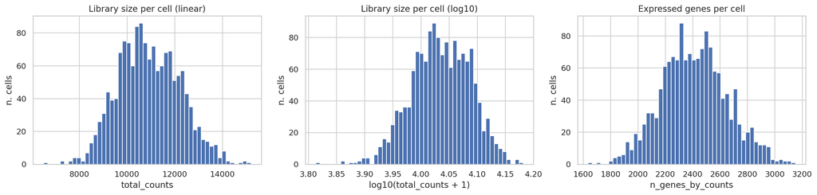

```
Per-cell histograms saved to: figs_descriptive/cells_library_genes_hist.png
```

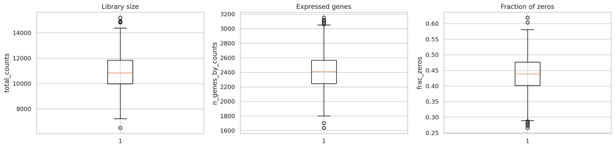

```
Per-cell boxplots saved to: figs_descriptive/cells_library_genes_box.png
--- End of section: Per-cell statistics: library size, expressed genes, sparsity ---
```

```python
# Basic per-cell QC statistics

with section("Per-cell statistics: library size, expressed genes, sparsity"):
    X = adata.X  # expression matrix (n_cells × n_genes)
    n_cells, n_genes = adata.n_obs, adata.n_vars

    # Library size and number of non-zero entries per cell
    if sparse.issparse(X):
        total_counts = safe_to_1d(X.sum(axis=1))
        if sparse.isspmatrix_csr(X):
            nnz_per_cell = np.diff(X.indptr)
        else:
            nnz_per_cell = np.array((X != 0).sum(axis=1)).ravel()
    else:
        total_counts = X.sum(axis=1)
        nnz_per_cell = (X != 0).sum(axis=1)

    total_counts = safe_to_1d(total_counts).astype(float)
    n_genes_by_counts = safe_to_1d(nnz_per_cell).astype(float)
    frac_zeros = 1.0 - (n_genes_by_counts / float(n_genes))

    # Store in adata.obs for later use
    adata.obs["total_counts"] = total_counts
    adata.obs["n_genes_by_counts"] = n_genes_by_counts
    adata.obs["frac_zeros"] = frac_zeros

    # Numeric summaries
    describe_vector(total_counts,      "total_counts (library size per cell)")
    describe_vector(n_genes_by_counts, "n_genes_by_counts (expressed genes per cell)")
    describe_vector(frac_zeros,        "frac_zeros (fraction of zeros per cell)")

    # Histograms
    fig, axes = plt.subplots(1, 3, figsize=(16, 4))

    axes[0].hist(total_counts, bins=50)
    axes[0].set_title("Library size per cell (linear)")
    axes[0].set_xlabel("total_counts")
    axes[0].set_ylabel("n. cells")

    axes[1].hist(np.log10(total_counts + 1), bins=50)
    axes[1].set_title("Library size per cell (log10)")
    axes[1].set_xlabel("log10(total_counts + 1)")
    axes[1].set_ylabel("n. cells")

    axes[2].hist(n_genes_by_counts, bins=50)
    axes[2].set_title("Expressed genes per cell")
    axes[2].set_xlabel("n_genes_by_counts")
    axes[2].set_ylabel("n. cells")

    plt.tight_layout()
    hist_path = FIG_DIR / "cells_library_genes_hist.png"
    fig.savefig(hist_path, dpi=150)
    plt.show()
    plt.close(fig)
    log(f"Per-cell histograms saved to: {hist_path}")

    # Boxplots
    fig2, axes2 = plt.subplots(1, 3, figsize=(16, 4))

    axes2[0].boxplot(total_counts, vert=True, showfliers=True)
    axes2[0].set_title("Library size")
    axes2[0].set_ylabel("total_counts")

    axes2[1].boxplot(n_genes_by_counts, vert=True, showfliers=True)
    axes2[1].set_title("Expressed genes")
    axes2[1].set_ylabel("n_genes_by_counts")

    axes2[2].boxplot(frac_zeros, vert=True, showfliers=True)
    axes2[2].set_title("Fraction of zeros")
    axes2[2].set_ylabel("frac_zeros")

    plt.tight_layout()
    box_path = FIG_DIR / "cells_library_genes_box.png"
    fig2.savefig(box_path, dpi=150)
    plt.show()
    plt.close(fig2)
    log(f"Per-cell boxplots saved to: {box_path}")
```

## Per-gene statistics

Here we move to the gene level and, for each gene, compute:

- `n_cells_expressed` and `detection_rate`,
- `mean_expr` and `var_expr`,
- `cv2_expr = var / mean²`.

These are stored in `adata.var`, summarized numerically, and visualized via:

- histograms of detection rate, sparsity and log10(mean expression),
- a log–log mean–variance scatter plot highlighting technical vs biological variability.

We also keep a dense copy of the expression matrix (`Xd`) for later reuse.

In this dataset, genes span the full range of detection rates, with many genes either very rarely expressed or almost ubiquitous across cells:

- the median detection rate is ~0.60 (≈900 cells), but there are clear peaks near 0 and 1,
- the corresponding per-gene sparsity histogram mirrors this, with many genes either almost always zero or almost always non-zero.

Mean expression levels are right-skewed:

- typical genes have mean expression between ~0.6 and ~4 (on the raw scale),
- only a minority of genes reach very high average expression.

```
=== Per-gene statistics: detection rate, sparsity, variance, CV² ===

--- n_cells_expressed (number of cells with gene > 0) ---
  min   = 3.000
  p05   = 77.450
  p25   = 400.000
  median= 898.000
  mean  = 842.766
  p75   = 1296.750
  p95   = 1490.000
  max   = 1499.000

--- detection_rate (fraction of cells with gene > 0) ---
  min   = 0.002
  p05   = 0.052
  p25   = 0.267
  median= 0.599
  mean  = 0.562
  p75   = 0.865
  p95   = 0.994
  max   = 1.000

--- mean_expr (mean expression per gene) ---
  min   = 0.003
  p05   = 0.093
  p25   = 0.613
  median= 1.970
  mean  = 2.546
  p75   = 3.891
  p95   = 7.036
  max   = 13.299

--- cv2_expr (var / mean^2) ---
  min   = 0.003
  p05   = 0.149
  p25   = 0.645
  median= 1.740
  mean  = 8.567
  p75   = 5.884
  p95   = 35.921
  max   = 660.191
```

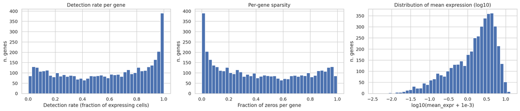

```
Per-gene histograms saved to: figs_descriptive/genes_detection_sparsity_hist.png
```

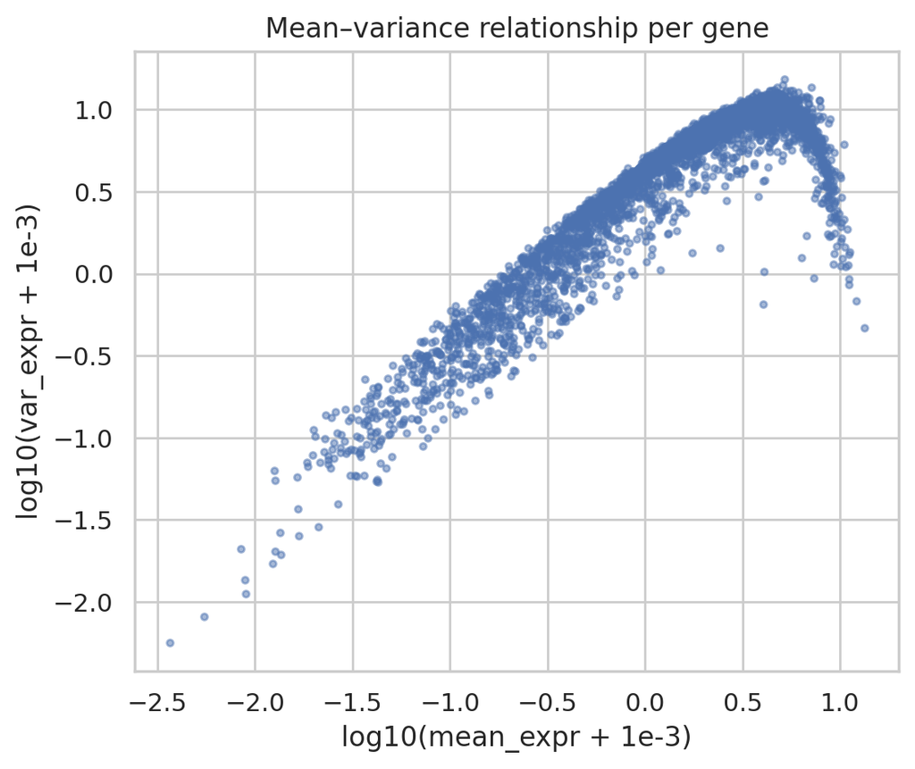

```
Per-gene mean–variance scatter saved to: figs_descriptive/genes_mean_variance_scatter.png
--- End of section: Per-gene statistics: detection rate, sparsity, variance, CV² ---
```

```python
# Per-gene statistics: detection rate, sparsity, variance, CV²

with section("Per-gene statistics: detection rate, sparsity, variance, CV²"):
    # Dense copy reused in later sections
    Xd = to_dense(adata.X).astype(float)
    n_cells, n_genes = Xd.shape

    n_cells_expressed = (Xd > 0).sum(axis=0)
    detection_rate = n_cells_expressed / float(n_cells)
    frac_zeros_gene = 1.0 - detection_rate

    mean_expr = Xd.mean(axis=0)
    var_expr = Xd.var(axis=0)

    eps = 1e-8
    cv2_expr = var_expr / (mean_expr**2 + eps)

    # Store in adata.var
    adata.var["n_cells_expressed"] = n_cells_expressed
    adata.var["detection_rate"] = detection_rate
    adata.var["frac_zeros_gene"] = frac_zeros_gene
    adata.var["mean_expr"] = mean_expr
    adata.var["var_expr"] = var_expr
    adata.var["cv2_expr"] = cv2_expr

    # Numeric summaries
    describe_vector(n_cells_expressed, "n_cells_expressed (number of cells with gene > 0)")
    describe_vector(detection_rate,    "detection_rate (fraction of cells with gene > 0)")
    describe_vector(mean_expr,         "mean_expr (mean expression per gene)")
    describe_vector(cv2_expr,          "cv2_expr (var / mean^2)")

    # Histograms
    fig, axes = plt.subplots(1, 3, figsize=(18, 4))

    axes[0].hist(detection_rate, bins=40)
    axes[0].set_xlabel("Detection rate (fraction of expressing cells)")
    axes[0].set_ylabel("n. genes")
    axes[0].set_title("Detection rate per gene")

    axes[1].hist(frac_zeros_gene, bins=40)
    axes[1].set_xlabel("Fraction of zeros per gene")
    axes[1].set_ylabel("n. genes")
    axes[1].set_title("Per-gene sparsity")

    log_mean = np.log10(mean_expr + 1e-3)
    axes[2].hist(log_mean, bins=40)
    axes[2].set_xlabel("log10(mean_expr + 1e-3)")
    axes[2].set_ylabel("n. genes")
    axes[2].set_title("Distribution of mean expression (log10)")

    plt.tight_layout()
    fig_path_hist = FIG_DIR / "genes_detection_sparsity_hist.png"
    fig.savefig(fig_path_hist, dpi=150)
    plt.show()
    plt.close(fig)
    log(f"Per-gene histograms saved to: {fig_path_hist}")

    # Mean–variance scatter (log10–log10)
    fig, ax = plt.subplots(figsize=(6, 5))
    ax.scatter(
        np.log10(mean_expr + 1e-3),
        np.log10(var_expr + 1e-3),
        s=8, alpha=0.5
    )
    ax.set_xlabel("log10(mean_expr + 1e-3)")
    ax.set_ylabel("log10(var_expr + 1e-3)")
    ax.set_title("Mean–variance relationship per gene")
    scatter_path = FIG_DIR / "genes_mean_variance_scatter.png"
    fig.savefig(scatter_path, dpi=150)
    plt.show()
    plt.close(fig)
    log(f"Per-gene mean–variance scatter saved to: {scatter_path}")
```

### Biological per-cell QC by gene family

Using gene symbols (either from `adata.var['Symbol']` or from `var_names`) we define four coarse gene families:

- mitochondrial (`mt`),
- ribosomal (`ribo`),
- hemoglobin / erythroid (`hemo`),
- immunoglobulin / TCR (`ig`).

For each family and each cell we compute:

- `pct_counts_<fam>`: percentage of total counts contributed by that family,
- `n_genes_<fam>`: number of expressed genes in that family.

We summarize and export these metrics and visualize the distributions of `% counts` per family via histograms and a boxplot.

In this dataset, the simple prefix-based search used here does **not** identify any mitochondrial genes (`Genes mt: 0`). This likely reflects naming conventions or upstream filtering, rather than an absence of mitochondrial genes per se. The code is written in a way that would handle mitochondrial genes in other datasets, so the analysis remains generalisable.

For the other families:

```
=== Biological per-cell QC metrics (mt / ribo / hemo / Ig) ===
Genes mt: 0
Genes ribo: 8
Genes hemo: 4
Genes ig: 50

--- % ribo counts ---
  min   = 0.052
  p05   = 0.148
  p25   = 0.211
  median= 0.254
  mean  = 0.253
  p75   = 0.296
  p95   = 0.351
  max   = 0.441

--- n. ribo genes expressed ---
  min   = 2.000
  p05   = 3.000
  p25   = 5.000
  median= 5.000
  mean  = 5.226
  p75   = 6.000
  p95   = 7.000
  max   = 8.000

--- % hemo counts ---
  min   = 0.000
  p05   = 0.000
  p25   = 0.000
  median= 0.021
  mean  = 0.046
  p75   = 0.068
  p95   = 0.182
  max   = 0.404

--- n. hemo genes expressed ---
  min   = 0.000
  p05   = 0.000
  p25   = 0.000
```

[output cut: 11 more lines]

```
  mean  = 0.332
  p75   = 0.415
  p95   = 0.646
  max   = 1.159

--- n. ig genes expressed ---
  min   = 1.000
  p05   = 4.000
  p25   = 6.000
  median= 8.000
  mean  = 8.467
  p75   = 10.000
  p95   = 15.000
  max   = 23.000
Biological per-cell QC metrics saved to: descriptive_outputs/per_cell_biological_qc_metrics.csv
```

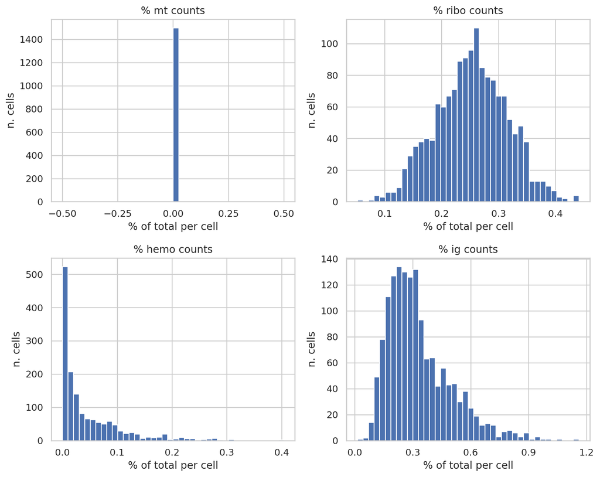

```
Histograms of % counts per family saved to: figs_descriptive/per_cell_biological_qc_hist_pct_counts.png
```

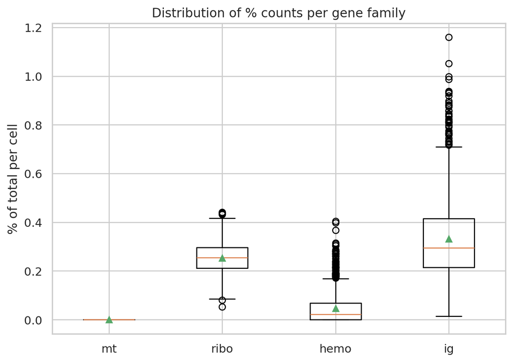

```
Boxplot of % counts per family saved to: figs_descriptive/per_cell_biological_qc_box_pct_counts.png
--- End of section: Biological per-cell QC metrics (mt / ribo / hemo / Ig) ---
```

```python
# Biological per-cell QC metrics by gene family

with section("Biological per-cell QC metrics (mt / ribo / hemo / Ig)"):
    # Reuse dense expression matrix if available; otherwise create it
    try:
        Xd
    except NameError:
        Xd = to_dense(adata.X).astype(float)

    # Gene symbols
    adata.var_names = adata.var_names.astype(str)
    if "Symbol" in adata.var.columns:
        sym = adata.var["Symbol"].astype("string").fillna("")
    else:
        sym = adata.var_names.astype("string")
    sym_up = sym.str.upper().values

    # Gene family masks (coarse but standard patterns)
    mito_mask = np.array([s.startswith(("MT-", "MT_", "MT.")) for s in sym_up])
    ribo_mask = np.array([s.startswith(("RPL", "RPS", "MRPL", "MRPS")) for s in sym_up])
    hemo_mask = np.array([s.startswith(("HBA", "HBB", "HBD", "HBM", "HBZ", "HBE", "HBG")) for s in sym_up])
    ig_mask   = np.array([s.startswith(("IGH", "IGL", "IGK", "TRB", "TRA", "TRG", "TRD")) for s in sym_up])

    fam_masks = {
        "mt":   mito_mask,   # 'mt' matches Scanpy's pct_counts_mt convention
        "ribo": ribo_mask,
        "hemo": hemo_mask,
        "ig":   ig_mask,
    }

    # Log number of genes per family
    for fam, m in fam_masks.items():
        log(f"Genes {fam}: {int(m.sum())}")

    total_counts = adata.obs["total_counts"].values.astype(float)
    total_counts[total_counts == 0] = 1.0  # avoid division by zero

    # Per-cell metrics: % counts and # expressed genes per family
    qc_bio_cols = []
    for fam, mask in fam_masks.items():
        pct_col = f"pct_counts_{fam}"
        n_col = f"n_genes_{fam}"
        qc_bio_cols.extend([pct_col, n_col])

        if mask.sum() == 0:
            adata.obs[pct_col] = 0.0
            adata.obs[n_col] = 0
            continue

        X_sub = Xd[:, mask]

        fam_counts = X_sub.sum(axis=1)
        adata.obs[pct_col] = (fam_counts / total_counts) * 100.0
        adata.obs[n_col] = (X_sub > 0).sum(axis=1)

        describe_vector(adata.obs[pct_col], f"% {fam} counts")
        describe_vector(adata.obs[n_col],   f"n. {fam} genes expressed")

    # Save per-cell biological QC metrics
    qc_bio_df = adata.obs[qc_bio_cols].copy()
    out_csv = DESCR_DIR / "per_cell_biological_qc_metrics.csv"
    qc_bio_df.to_csv(out_csv, index=True)
    log(f"Biological per-cell QC metrics saved to: {out_csv}")

    # Histograms of % counts per family
    fam_list = list(fam_masks.keys())
    fig, axes = plt.subplots(2, 2, figsize=(10, 8))
    for ax, fam in zip(axes.ravel(), fam_list):
        vals = adata.obs[f"pct_counts_{fam}"].values
        ax.hist(vals, bins=40)
        ax.set_title(f"% {fam} counts")
        ax.set_xlabel("% of total per cell")
        ax.set_ylabel("n. cells")
        ax.xaxis.set_major_locator(MaxNLocator(nbins=5))

    plt.tight_layout()
    hist_path = FIG_DIR / "per_cell_biological_qc_hist_pct_counts.png"
    fig.savefig(hist_path, dpi=150)
    plt.show()
    plt.close(fig)
    log(f"Histograms of % counts per family saved to: {hist_path}")

    # Boxplot of % counts per family
    fig, ax = plt.subplots(figsize=(7, 5))
    data = [adata.obs[f"pct_counts_{fam}"].values for fam in fam_list]
    ax.boxplot(data, labels=fam_list, showmeans=True)
    ax.set_ylabel("% of total per cell")
    ax.set_title("Distribution of % counts per gene family")
    plt.tight_layout()
    box_path = FIG_DIR / "per_cell_biological_qc_box_pct_counts.png"
    fig.savefig(box_path, dpi=150)
    plt.show()
    plt.close(fig)
    log(f"Boxplot of % counts per family saved to: {box_path}")
```

### Top genes by mean expression, detection rate and CV²

Using the per-gene statistics in `adata.var`, we build a `gene_stats_df` table and extract the top 20 genes ranked by:

1. highest mean expression,
2. highest detection rate,
3. highest CV² (most variable).

We export the full per-gene table and the three top-20 lists, and visualize each list as a horizontal barplot.  
These summaries highlight highly expressed "core" genes and highly variable candidate marker genes.

In this dataset:

```
=== Top genes: mean, detection rate, variability ===
per-gene basic stats saved to: descriptive_outputs/per_gene_basic_stats.csv
Top-20 gene tables saved in DESCR_DIR
```

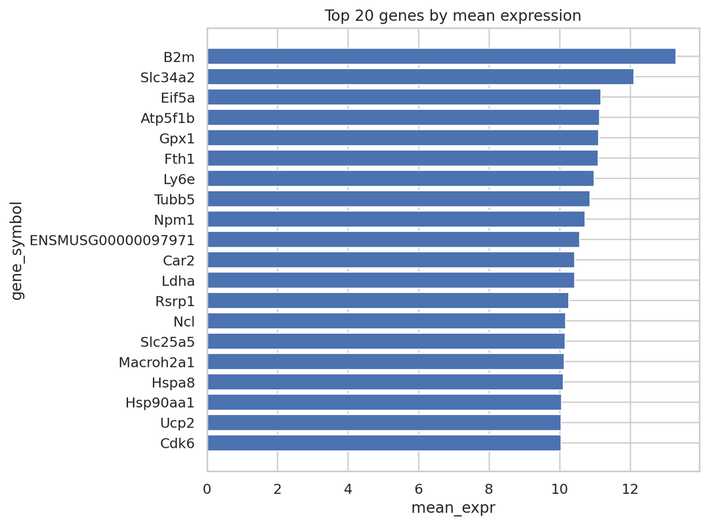

```
Barplot 'Top 20 genes by mean expression' saved to: figs_descriptive/top_genes_mean_expr_bar.png
```

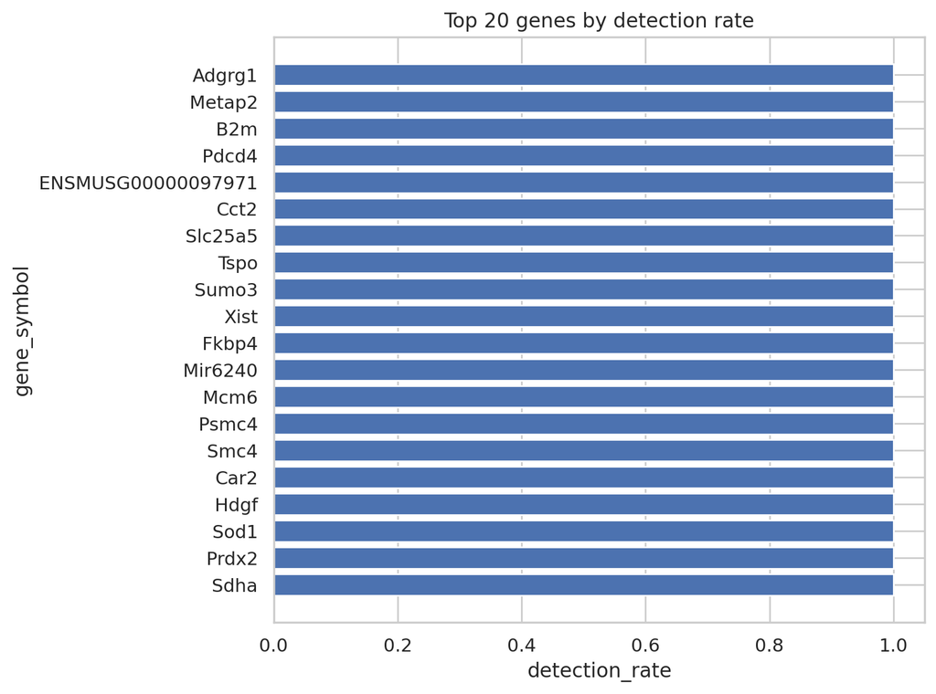

```
Barplot 'Top 20 genes by detection rate' saved to: figs_descriptive/top_genes_detection_rate_bar.png
```

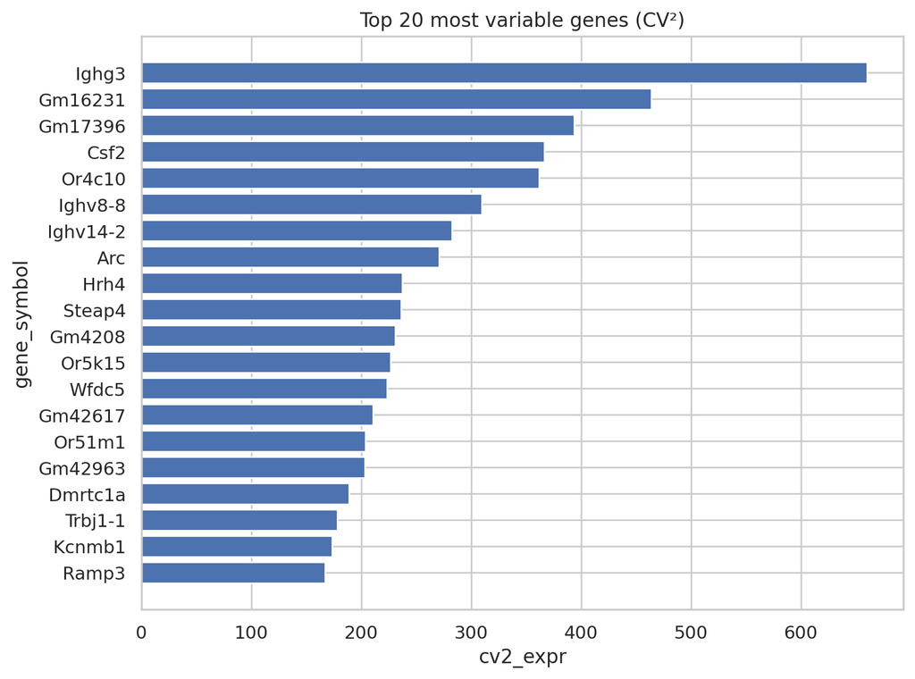

```
Barplot 'Top 20 most variable genes (CV²)' saved to: figs_descriptive/top_genes_cv2_expr_bar.png
--- End of section: Top genes: mean, detection rate, variability ---
```

```python
# Top genes: mean, detection rate, variability

with section("Top genes: mean, detection rate, variability"):
    # Build per-gene stats DataFrame from adata.var
    gene_ids = adata.var_names.astype(str).values
    if "Symbol" in adata.var.columns:
        gene_symbols = adata.var["Symbol"].astype(str).values
    else:
        gene_symbols = gene_ids

    n_cells_expressed = adata.var["n_cells_expressed"].to_numpy()
    detection_rate = adata.var["detection_rate"].to_numpy()
    mean_expr = adata.var["mean_expr"].to_numpy()
    var_expr = adata.var["var_expr"].to_numpy()
    cv2_expr = adata.var["cv2_expr"].to_numpy()

    gene_stats_df = pd.DataFrame({
        "gene_id": gene_ids,
        "gene_symbol": gene_symbols,
        "n_cells_expressed": n_cells_expressed,
        "detection_rate": detection_rate,
        "mean_expr": mean_expr,
        "var_expr": var_expr,
        "cv2_expr": cv2_expr,
    })

    out_stats_path = DESCR_DIR / "per_gene_basic_stats.csv"
    gene_stats_df.to_csv(out_stats_path, index=False)
    log(f"per-gene basic stats saved to: {out_stats_path}")

    # Top lists
    top_mean = gene_stats_df.sort_values("mean_expr", ascending=False).head(20).copy()
    top_det = gene_stats_df.sort_values("detection_rate", ascending=False).head(20).copy()
    top_cv2 = gene_stats_df.sort_values("cv2_expr", ascending=False).head(20).copy()

    top_mean.to_csv(DESCR_DIR / "top20_genes_by_mean_expr.csv", index=False)
    top_det.to_csv(DESCR_DIR / "top20_genes_by_detection_rate.csv", index=False)
    top_cv2.to_csv(DESCR_DIR / "top20_genes_by_cv2_expr.csv", index=False)
    log("Top-20 gene tables saved in DESCR_DIR")

    def plot_top_genes_bar(df, value_col, title, out_name):
        order = df.sort_values(value_col, ascending=True)
        fig, ax = plt.subplots(figsize=(8, 6))
        ax.barh(order["gene_symbol"].astype(str), order[value_col])
        ax.set_xlabel(value_col)
        ax.set_ylabel("gene_symbol")
        ax.set_title(title)
        plt.tight_layout()
        out_path = FIG_DIR / out_name
        fig.savefig(out_path, dpi=150)
        plt.show()
        plt.close(fig)
        log(f"Barplot '{title}' saved to: {out_path}")

    plot_top_genes_bar(
        top_mean, "mean_expr",
        "Top 20 genes by mean expression",
        "top_genes_mean_expr_bar.png"
    )
    plot_top_genes_bar(
        top_det, "detection_rate",
        "Top 20 genes by detection rate",
        "top_genes_detection_rate_bar.png"
    )
    plot_top_genes_bar(
        top_cv2, "cv2_expr",
        "Top 20 most variable genes (CV²)",
        "top_genes_cv2_expr_bar.png"
    )
```

### Class distribution in the training CSV

We read the training metadata from `singlecell_train.csv`, assuming columns:

- `ID` (cell identifier),
- `cell_type` (class label).

The cell prints the counts per class, produces a barplot of class frequencies, and (optionally) attaches a `train_label` column to `adata.obs` by matching `ID` to `adata.obs_names`.

This provides a quick view of class imbalance and prepares the labels for later visualization.

In this dataset the class distribution is **strongly imbalanced**:  
MEP_broad and CMP_broad together account for almost half of all labelled cells, followed by LMPP_broad and MPP3_broad, while rare classes like MPP2_broad (15 cells) and `other` (6 cells) represent well under 2 % of the training set. This has direct implications for supervised models (e.g. the need for class-weighting, careful evaluation metrics, or resampling strategies) and also for interpreting embeddings where small classes may be visually swamped by the major ones.

```
=== Class distribution in the training file ===
Number of observations per class:
cell_type
MEP_broad      256
CMP_broad      232
LMPP_broad     176
MPP3_broad     110
GMP_broad       88
LTHSC_broad     75
STHSC_broad     73
MPP1_broad      43
MPP2_broad      15
other            6
Name: count, dtype: int64
```

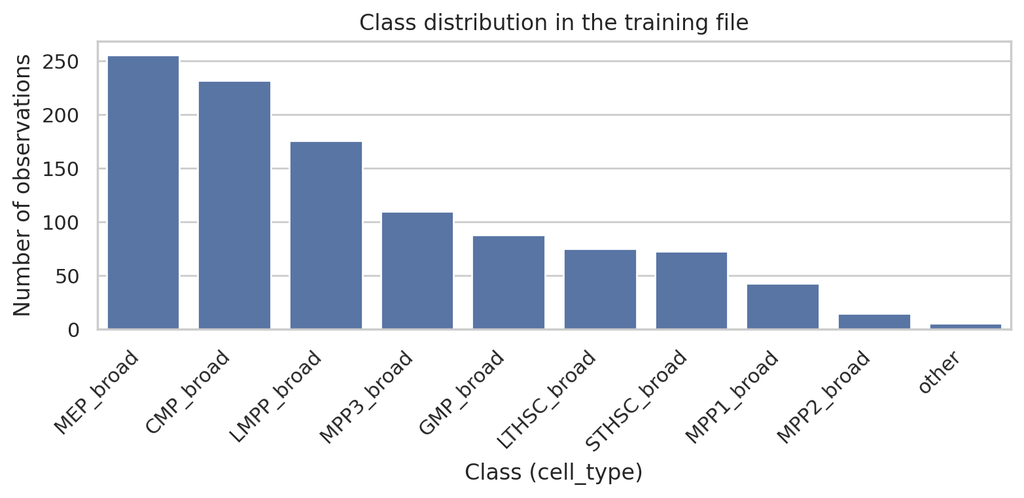

```
Class distribution barplot saved to: figs_descriptive/train_class_distribution.png
Using adata.obs['ID'] to match training labels.
Attached 'train_label' to adata.obs for 1074 / 1499 cells
--- End of section: Class distribution in the training file ---
```

```python
# Class distribution in the training CSV

with section("Class distribution in the training file"):
    train_df = pd.read_csv(TRAIN_CSV_PATH)
    assert TRAIN_LABEL_COL in train_df.columns, f"Column '{TRAIN_LABEL_COL}' not found in {TRAIN_CSV_PATH}"

    class_counts = train_df[TRAIN_LABEL_COL].value_counts().sort_values(ascending=False)

    print("Number of observations per class:")
    print(class_counts)

    plt.figure(figsize=(8, 4))
    sns.barplot(
        x=class_counts.index,
        y=class_counts.values
    )
    plt.xticks(rotation=45, ha="right")
    plt.ylabel("Number of observations")
    plt.xlabel("Class (cell_type)")
    plt.title("Class distribution in the training file")
    plt.tight_layout()

    out_path = FIG_DIR / "train_class_distribution.png"
    plt.savefig(out_path, dpi=150)
    plt.show()
    plt.close()

    log(f"Class distribution barplot saved to: {out_path}")

    # Attach labels to adata based on TRAIN_ID_COL
    # We first try to match using an 'ID' column in adata.obs, otherwise we fall back to obs_names.
    train_df[TRAIN_ID_COL] = train_df[TRAIN_ID_COL].astype("string")
    train_df[TRAIN_LABEL_COL] = train_df[TRAIN_LABEL_COL].astype("string")

    id_to_label = (
        train_df[[TRAIN_ID_COL, TRAIN_LABEL_COL]]
        .drop_duplicates(subset=[TRAIN_ID_COL])
        .set_index(TRAIN_ID_COL)[TRAIN_LABEL_COL]
    )

    if TRAIN_ID_COL in adata.obs.columns:
        log(f"Using adata.obs['{TRAIN_ID_COL}'] to match training labels.")
        obs_ids = adata.obs[TRAIN_ID_COL].astype("string")
    else:
        log(f"Column '{TRAIN_ID_COL}' not found in adata.obs; matching labels to adata.obs_names.")
        obs_ids = pd.Series(adata.obs_names.astype(str), index=adata.obs_names, name=TRAIN_ID_COL)

    train_label = obs_ids.map(id_to_label)

    adata.obs["train_label"] = train_label.astype("category")
    n_labeled = adata.obs["train_label"].notna().sum()

    log(f"Attached 'train_label' to adata.obs for {n_labeled} / {adata.n_obs} cells")
```

# 2. Dimensionality reduction

# 2.1 Pca

```python
adata = sc.read_h5ad("/content/single_cell.h5ad")

df = pd.read_csv("/content/singlecell_train.csv")


adata.obs["ID"] = adata.obs["ID"].astype(str)
df["ID"] = df["ID"].astype(str)



id_to_label = dict(zip(df["ID"], df["cell_type"]))


adata.obs["train_label"] = adata.obs["ID"].map(id_to_label)
```

```python
import scipy.sparse as sp
import pandas as pd

X = adata.X.toarray() if sp.issparse(adata.X) else adata.X

features_df = pd.DataFrame(
    X,
    index=adata.obs_names,
    columns=adata.var_names
)

features_df["cell_type"] = adata.obs["train_label"].values

features_df.to_csv("single_cell_with_labels.csv")
```

```python
import numpy as np
import pandas as pd

try:
    import anndata as ad
except ImportError:
    ad = None

from sklearn.cluster import KMeans
import numpy as np

def bisecting_kmeans(X, n_clusters=5, random_state=0, n_init=10):



    clusters = {0: np.arange(X.shape[0])}
    current_k = 1

    while current_k < n_clusters:

        max_sse = -1
        cluster_to_split = None

        for c_id, idx in clusters.items():
            if len(idx) <= 1:
                continue
            X_sub = X[idx]
            center = X_sub.mean(axis=0)
            sse = ((X_sub - center)**2).sum()

            if sse > max_sse:
                max_sse = sse
                cluster_to_split = c_id


        idx = clusters[cluster_to_split]
        X_sub = X[idx]

        km = KMeans(n_clusters=2, random_state=random_state, n_init=n_init)
        sub_labels = km.fit_predict(X_sub)


        new_id_1 = max(clusters.keys()) + 1
        new_id_2 = new_id_1 + 1

        clusters[new_id_1] = idx[sub_labels == 0]
        clusters[new_id_2] = idx[sub_labels == 1]

        del clusters[cluster_to_split]
        current_k += 1


    labels = np.zeros(X.shape[0], dtype=int)
    for label_id, idx in clusters.items():
        labels[idx] = label_id


    _, labels_remapped = np.unique(labels, return_inverse=True)
    return labels_remapped



def _to_dense(X):

    if hasattr(X, "A"):
        return X.A
    if hasattr(X, "toarray"):
        return X.toarray()
    return np.asarray(X)


def get_symbol_series_upper(adata, symbol_col: str = "Symbol") -> pd.Series:

    idx = adata.var_names.astype(str)

    if symbol_col in adata.var.columns:
        s = pd.Series(adata.var[symbol_col], index=idx)
    else:
        s = pd.Series(idx, index=idx)

    # Convert to string dtype, tolerate nulls, then uppercase
    s = s.astype("string").fillna("")
    return s.str.upper()


def biology_filter_mask(adata,
                        level: str = "mild",
                        symbol_col: str = "Symbol") -> np.ndarray:

    # Normalize gene symbols to uppercase strings
    su = get_symbol_series_upper(adata, symbol_col=symbol_col)
    up = su.values  # numpy array of uppercase gene symbols

    #  Basic gene category masks
    # 1) Mitochondrial genes (commonly high in stressed/dying cells)
    mito = np.array([s.startswith(("MT-", "MT_", "MT.")) for s in up])

    # 2) Ribosomal genes (very abundant, often dominate variability)
    ribo = np.array([
        s.startswith(("RPL", "RPS", "MRPL", "MRPS")) for s in up
    ])

    # 3) Hemoglobin genes (e.g. erythroid contamination / blood)
    hemo = np.array([
        s.startswith(("HBA", "HBB", "HBD", "HBM", "HBZ", "HBE", "HBG"))
        for s in up
    ])

    # 4) Immunoglobulin & T-cell receptor genes (B/T cell clonality, noisy)
    ig = np.array([
        s.startswith(("IGH", "IGL", "IGK", "TRB", "TRA", "TRG", "TRD"))
        for s in up
    ])

    # 5) Cell-cycle genes (S phase + G2/M), used only in "aggressive"
    S_genes = {
        g.upper() for g in [
            "MCM5","PCNA","TYMS","FEN1","MCM2","MCM4","RRM1","UNG","GINS2",
            "MCM6","CDCA7","DTL","PRIM1","UHRF1","HELLS","RFC2","RPA2",
            "NASP","RAD51AP1","GMNN","WDR76","SLBP","CCNE2","UBR7","POLD3",
            "MSH2","ATAD2","RAD51","RRM2","CDC45","CDC6","EXO1","TIPIN",
            "DSCC1","BLM","CASP8AP2","USP1","CLSPN","POLA1","CHAF1B","BRIP1",
            "E2F8"
        ]
    }
    G2M_genes = {
        g.upper() for g in [
            "HMGB2","CDK1","NUSAP1","UBE2C","BIRC5","TPX2","TOP2A","NDC80",
            "CKS2","NUF2","CKS1B","MKI67","TMPO","CENPF","TACC3","FAM64A",
            "SMC4","CCNB2","CKAP2L","CKAP2","AURKB","BUB1","KIF11","ANP32E",
            "TUBB4B","GTSE1","KIF20B","HJURP","CDCA3","HN1","CDC20","TTK",
            "CDC25C","KIF2C","RANGAP1","NCAPD2","DLGAP5","CDCA2","CDCA8",
            "ECT2","KIF23","HMMR","AURKA","PSRC1","ANLN","LBR","CKAP5",
            "CENPE","CTCF","NEK2","G2E3","GAS2L3","CBX5","CENPA"
        ]
    }
    cc = su.isin(S_genes | G2M_genes).values  # cell-cycle mask

    # 6) Sex-chromosome marker genes
    sex_marker_set = {
        "XIST", "XACT",       # X-inactivation / X-related
        "RPS4Y1","DDX3Y","KDM5D","EIF1AY","UTY"  # Y-chromosome markers
    }
    sex = np.array([s in sex_marker_set for s in up])

    # Start with all genes kept
    keep = np.ones(len(up), dtype=bool)

    # Level-specific logic
    if level == "none":
        # No filtering at all
        return keep

    if level == "mild":
        # Drop only mitochondrial and ribosomal genes.
        # These often dominate technical variability and can dilute signal
        # from more informative genes.
        keep = ~(mito | ribo)
        return keep

    if level == "medium":
        # Drop mito + ribo + hemoglobin + immunoglobulin/TCR.
        # Hemoglobin and Ig/TCR genes can reflect tissue contamination
        # (blood, immune clonality) rather than the biology of interest.
        keep = ~(mito | ribo | hemo | ig)
        return keep

    if level == "aggressive":
        # Start from medium filter:
        base_drop = mito | ribo | hemo | ig | cc | sex

        # Additional data-driven pruning of "uninformative" but highly
        # expressed genes: high mean, low variance.
        Xd = _to_dense(adata.X)
        means = np.asarray(Xd.mean(axis=0)).ravel()
        vars_ = np.asarray(Xd.var(axis=0)).ravel()

        # High-mean genes: top 5% of mean expression
        hi_mean = means >= np.quantile(means, 0.95)

        # Low-variance genes: bottom 20% of variance
        lo_var = vars_ <= np.quantile(vars_, 0.20)

        # Genes that are both highly expressed and low variance are often
        # "background" or housekeeping-like and can wash out subtle signals.
        extra_drop = hi_mean & lo_var

        keep = ~(base_drop | extra_drop)
        return keep

    # Fallback: if a typo in level is provided, be safe and return all genes
    # (or you could raise an error instead).
    raise ValueError(f"Unknown biology filter level: {level!r}. "
                     "Expected one of: 'none', 'mild', 'medium', 'aggressive'.")


def apply_biology_filter(adata,
                         level: str = "mild",
                         symbol_col: str = "Symbol",
                         copy: bool = True):

    keep = biology_filter_mask(adata, level=level, symbol_col=symbol_col)

    if copy:
        adata_filtered = adata[:, keep].copy()
    else:
        # in-place subsetting modifies adata; no copy made
        adata._inplace_subset_var(keep)
        adata_filtered = adata

    return adata_filtered, keep
```

```python
import numpy as np
import pandas as pd
import scipy.sparse as sp
import matplotlib.pyplot as plt

from sklearn.preprocessing import StandardScaler
from sklearn.decomposition import PCA
from sklearn.cluster import KMeans, AgglomerativeClustering
from sklearn.metrics import silhouette_score


 #Helpers


def to_dense(X):
    if sp.issparse(X):
        return X.toarray()
    return np.asarray(X)

def prepare_matrix(adata_in, method="A", n_hvg=2000):
    """
    METHOD A: HVG + scaling (z-score)
    METHOD B: All genes + centering only
    Ritorna:
      X      = matrice (cells x genes) preprocessata
      ad_use = AnnData (potenzialmente con solo HVG in var)
    """
    ad_use = adata_in.copy()

    if method == "A":
        # HVG + scaling
        import scanpy as sc
        sc.pp.highly_variable_genes(ad_use, n_top_genes=n_hvg, subset=True)
        X = to_dense(ad_use.X)
        scaler = StandardScaler(with_mean=True, with_std=True)
        X = scaler.fit_transform(X)
    elif method == "B":

        X = to_dense(ad_use.X)
        scaler = StandardScaler(with_mean=True, with_std=False)
        X = scaler.fit_transform(X)
    else:
        raise ValueError("method deve essere 'A' o 'B'")

    return X, ad_use


y_true_cat = adata.obs["train_label"].astype("category")
y_true = y_true_cat.cat.codes.values
true_label_names = list(y_true_cat.cat.categories)


n_clusters = len(true_label_names)


adata_unfiltered = adata
adata_filtered, _ = apply_biology_filter(adata, level="medium", copy=True)


# Grid search

methods = ["A", "B"]                     # PCA pipelines
pcs_list = [5, 10, 15, 20]               # #PCs
metrics = ["euclidean"]
linkages = ["single", "complete", "average"]
filters = [("unfiltered", adata_unfiltered),
           ("filtered_medium", adata_filtered)]

results = []

for filt_name, ad_base in filters:
    for method in methods:
        # Preprocess (HVG+scaling o all genes+centering)
        X_pre, ad_use = prepare_matrix(ad_base, method=method, n_hvg=2000)


        max_pcs = max(pcs_list)
        pca = PCA(n_components=max_pcs, random_state=0)
        X_pca_all = pca.fit_transform(X_pre)
        X_2d = X_pca_all[:, :2]  # per plotting (PC1 vs PC2)

        for n_pcs in pcs_list:
            X_pca = X_pca_all[:, :n_pcs]

            #KMEANS
            kmeans = KMeans(n_clusters=n_clusters, random_state=0, n_init=10)
            labels_km = kmeans.fit_predict(X_pca)

            sil = silhouette_score(X_pca, labels_km, metric="euclidean")
            run_desc = (f"{filt_name} | method={method} | PCs={n_pcs} | "
                        f"KMeans (k={n_clusters}) | metric=euclidean")
            results.append({
                "score": sil,
                "filt": filt_name,
                "method": method,
                "n_pcs": n_pcs,
                "algo": "kmeans",
                "linkage": None,
                "metric": "euclidean",
                "labels_pred": labels_km,
                "X_2d": X_2d,
                "desc": run_desc
            })


            #  AGGLOMERATIVE
            for linkage in linkages:
                for metric in metrics:
                    name = f"Agg-{linkage}-{metric}"
                    try:
                        if metric == "minkowski":

                            D = pairwise_distances(X_pca, metric="minkowski", p=3)
                            agg = AgglomerativeClustering(
                                n_clusters=n_clusters,
                                metric="precomputed",
                                linkage=linkage,
                            )
                            labels_agg = agg.fit_predict(D)
                            sil = silhouette_score(
                                X_pca, labels_agg, metric="minkowski", p=3
                            )
                        else:

                            agg = AgglomerativeClustering(
                                n_clusters=n_clusters,
                                metric=metric,
                                linkage=linkage,
                            )
                            labels_agg = agg.fit_predict(X_pca)
                            sil = silhouette_score(X_pca, labels_agg, metric=metric)

                        run_desc = (f"{filt_name} | method={method} | PCs={n_pcs} | "
                                    f"{name}")
                        results.append({
                            "score": sil,
                            "filt": filt_name,
                            "method": method,
                            "n_pcs": n_pcs,
                            "algo": "agg",
                            "linkage": linkage,
                            "metric": metric,
                            "labels_pred": labels_agg,
                            "X_2d": X_2d,
                            "desc": run_desc
                        })
                    except Exception as e:
                        print(f"Skipping {name} (error: {e})")


            # Bisecting K-Means
            labels_bkm = bisecting_kmeans(
                X_pca, n_clusters=n_clusters, random_state=0
            )

            sil = silhouette_score(X_pca, labels_bkm, metric="euclidean")
            run_desc = (f"{filt_name} | method={method} | PCs={n_pcs} | "
                        f"BisectingKMeans (k={n_clusters}) | metric=euclidean")
            results.append({
                "score": sil,
                "filt": filt_name,
                "method": method,
                "n_pcs": n_pcs,
                "algo": "bisecting_kmeans",
                "linkage": None,
                "metric": "euclidean",
                "labels_pred": labels_bkm,
                "X_2d": X_2d,
                "desc": run_desc
            })



results_df = pd.DataFrame(results).sort_values("score", ascending=False)
display(results_df.head(10))
```

|  | score | filt | method | n_pcs | algo | linkage | metric | labels_pred | X_2d | desc |
| --- | --- | --- | --- | --- | --- | --- | --- | --- | --- | --- |
| 16 | 0.448394 | unfiltered | A | 20 | agg | single | euclidean | [0, 0, 0, 0, 0, 0, 0, 0, 0, 0, 0, 0, 0, 0, 0, ... | [[-12.124261661626548, 0.2524529274550854], [-... | unfiltered \| method=A \| PCs=20 \| Agg-single-eu... |
| 13 | 0.394472 | unfiltered | A | 15 | agg | average | euclidean | [0, 0, 0, 3, 0, 0, 0, 0, 0, 0, 0, 0, 0, 0, 0, ... | [[-12.124261661626548, 0.2524529274550854], [-... | unfiltered \| method=A \| PCs=15 \| Agg-average-e... |
| 56 | 0.376812 | filtered_medium | A | 20 | agg | single | euclidean | [0, 0, 0, 0, 0, 0, 0, 0, 0, 0, 0, 0, 0, 0, 0, ... | [[-12.057039890291462, 0.28224923338546354], [... | filtered_medium \| method=A \| PCs=20 \| Agg-sing... |
| 58 | 0.376243 | filtered_medium | A | 20 | agg | average | euclidean | [1, 1, 1, 4, 1, 1, 1, 1, 1, 1, 1, 1, 1, 1, 1, ... | [[-12.057039890291462, 0.28224923338546354], [... | filtered_medium \| method=A \| PCs=20 \| Agg-aver... |
| 18 | 0.362358 | unfiltered | A | 20 | agg | average | euclidean | [8, 8, 8, 4, 8, 8, 8, 8, 8, 8, 8, 8, 8, 8, 8, ... | [[-12.124261661626548, 0.2524529274550854], [-... | unfiltered \| method=A \| PCs=20 \| Agg-average-e... |
| 8 | 0.342625 | unfiltered | A | 10 | agg | average | euclidean | [6, 6, 6, 0, 6, 6, 6, 6, 6, 6, 6, 6, 6, 6, 6, ... | [[-12.124261661626548, 0.2524529274550854], [-... | unfiltered \| method=A \| PCs=10 \| Agg-average-e... |
| 6 | 0.338063 | unfiltered | A | 10 | agg | single | euclidean | [1, 1, 1, 1, 1, 1, 1, 1, 1, 1, 1, 1, 1, 1, 1, ... | [[-12.124261661626548, 0.2524529274550854], [-... | unfiltered \| method=A \| PCs=10 \| Agg-single-eu... |
| 57 | 0.329227 | filtered_medium | A | 20 | agg | complete | euclidean | [0, 0, 0, 8, 0, 0, 0, 0, 0, 0, 0, 0, 0, 0, 0, ... | [[-12.057039890291462, 0.28224923338546354], [... | filtered_medium \| method=A \| PCs=20 \| Agg-comp... |
| 60 | 0.322407 | filtered_medium | B | 5 | kmeans | None | euclidean | [5, 5, 9, 0, 2, 7, 8, 7, 2, 1, 7, 9, 3, 4, 7, ... | [[-49.22257552538363, 2.422614505470935], [-44... | filtered_medium \| method=B \| PCs=5 \| KMeans (k... |
| 20 | 0.321918 | unfiltered | B | 5 | kmeans | None | euclidean | [6, 6, 7, 3, 9, 0, 8, 0, 9, 5, 0, 7, 2, 4, 0, ... | [[-49.59143843206396, 2.898797622414459], [-44... | unfiltered \| method=B \| PCs=5 \| KMeans (k=10) ... |

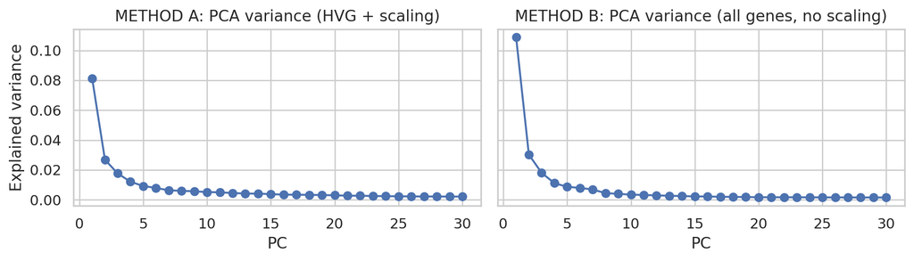

```python
import matplotlib.pyplot as plt
from sklearn.decomposition import PCA


adata_ref = adata_unfiltered

max_pcs = 30

# METHOD A: HVG + scaling
X_A, _ = prepare_matrix(adata_ref, method="A", n_hvg=2000)

pca_A = PCA(n_components=max_pcs, random_state=0)
pca_A.fit(X_A)
var_A = pca_A.explained_variance_ratio_

# METHOD B: all genes, mean-centering only
X_B, _ = prepare_matrix(adata_ref, method="B", n_hvg=2000)

pca_B = PCA(n_components=max_pcs, random_state=0)
pca_B.fit(X_B)
var_B = pca_B.explained_variance_ratio_

#  Plot side-by-side
pcs = range(1, max_pcs + 1)

fig, axes = plt.subplots(1, 2, figsize=(10, 3), sharey=True)

# Method A
axes[0].plot(pcs, var_A, marker="o")
axes[0].set_title("METHOD A: PCA variance (HVG + scaling)")
axes[0].set_xlabel("PC")
axes[0].set_ylabel("Explained variance")

# Method B
axes[1].plot(pcs, var_B, marker="o")
axes[1].set_title("METHOD B: PCA variance (all genes, no scaling)")
axes[1].set_xlabel("PC")


plt.tight_layout()
plt.show()
```

```
       score                                               desc
16  0.448394  unfiltered | method=A | PCs=20 | Agg-single-eu...
13  0.394472  unfiltered | method=A | PCs=15 | Agg-average-e...
56  0.376812  filtered_medium | method=A | PCs=20 | Agg-sing...
58  0.376243  filtered_medium | method=A | PCs=20 | Agg-aver...
18  0.362358  unfiltered | method=A | PCs=20 | Agg-average-e...
```

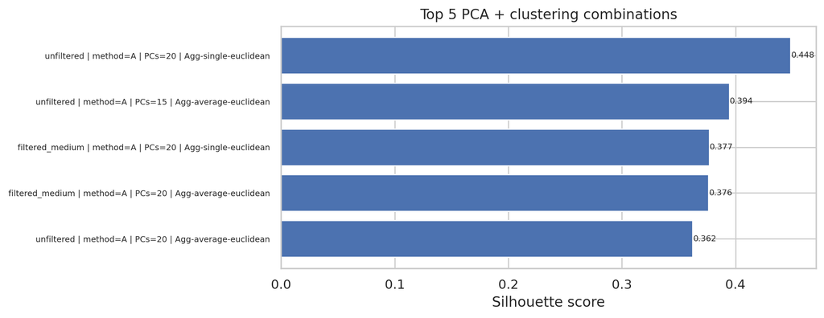

```python
top5 = results_df.head(5).copy()
print(top5[["score", "desc"]])


top5_sorted = top5.sort_values("score", ascending=True)

plt.figure(figsize=(10, 4))
y_pos = np.arange(len(top5_sorted))

plt.barh(y_pos, top5_sorted["score"].values)
plt.yticks(y_pos, top5_sorted["desc"].values, fontsize=7)

for i, (s) in enumerate(top5_sorted["score"].values):
    plt.text(s + 0.0005, i, f"{s:.3f}", va="center", fontsize=7)

plt.xlabel("Silhouette score")
plt.title("Top 5 PCA + clustering combinations")
plt.tight_layout()
plt.show()
```

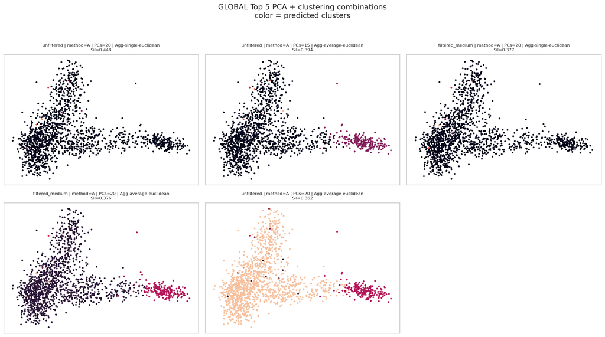

```python
top5_runs = top5.to_dict(orient="records")

fig = plt.figure(figsize=(16, 9))

for i, run in enumerate(top5_runs):
    ax = fig.add_subplot(2, 3, i+1)
    X_2d = run["X_2d"]
    labels_pred = run["labels_pred"]

    sc_plot = ax.scatter(
        X_2d[:, 0], X_2d[:, 1],
        c=labels_pred,
        s=5
    )
    ax.set_xticks([])
    ax.set_yticks([])
    ax.set_title(f"{run['desc']}\nSil={run['score']:.3f}", fontsize=8)

plt.suptitle("GLOBAL Top 5 PCA + clustering combinations\ncolor = predicted clusters",
             fontsize=14)
plt.tight_layout(rect=[0, 0, 1, 0.95])
plt.show()
```

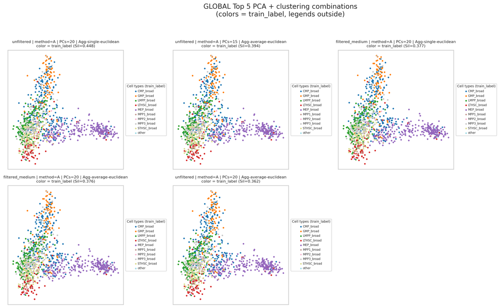

```python
import matplotlib.pyplot as plt
import numpy as np


top5_runs = top5.to_dict(orient="records")


true_label_names = list(y_true_cat.cat.categories)
n_classes = len(true_label_names)


cmap = plt.cm.get_cmap("tab20", n_classes)
colors_per_class = {cl: cmap(i) for i, cl in enumerate(true_label_names)}

fig = plt.figure(figsize=(16, 9))

for i, run in enumerate(top5_runs):
    ax = fig.add_subplot(2, 3, i+1)


    X_2d = run["X_2d"]


    handles = []
    for idx_cl, cl_name in enumerate(true_label_names):
        mask = (y_true == idx_cl)
        h = ax.scatter(
            X_2d[mask, 0],
            X_2d[mask, 1],
            s=5,
            color=colors_per_class[cl_name],
            label=cl_name
        )

        if i == 0:
            handles.append(h)

    ax.set_xticks([])
    ax.set_yticks([])
    ax.set_title(f"{run['desc']}\ncolor = train_label (Sil={run['score']:.3f})",
                 fontsize=8)


    ax.legend(
        title="Cell types (train_label)",
        bbox_to_anchor=(1.02, 0.5),
        loc="center left",
        borderaxespad=0.,
        fontsize=6,
        title_fontsize=7
    )

plt.suptitle(
    "GLOBAL Top 5 PCA + clustering combinations\n(colors = train_label, legends outside)",
    fontsize=14
)
plt.tight_layout(rect=[0, 0, 0.90, 0.95])
plt.show()
```